# act_report

## Introduction

Real-world data rarely comes clean. Using Python and its libraries, I will gather data from a variety of sources and in a variety of formats, assess its quality and tidiness, then clean it. This is called data wrangling.

The dataset that you will be wrangling (and analyzing and visualizing) is the tweet archive of Twitter user @dog_rates, also known as WeRateDogs. WeRateDogs is a Twitter account that rates people's dogs with a humorous comment about the dog.

## Analyzing and Visualizing Data

This project is about data wrangling steps, from gathering, assessing and cleaning the data.

After finishing all the wrangling three steps, comes the analysis part.

### Insights & Visualizations

#### 1- Does the number of tweets increase or decrease over time?

Obviously, number of retweets is changing over time.

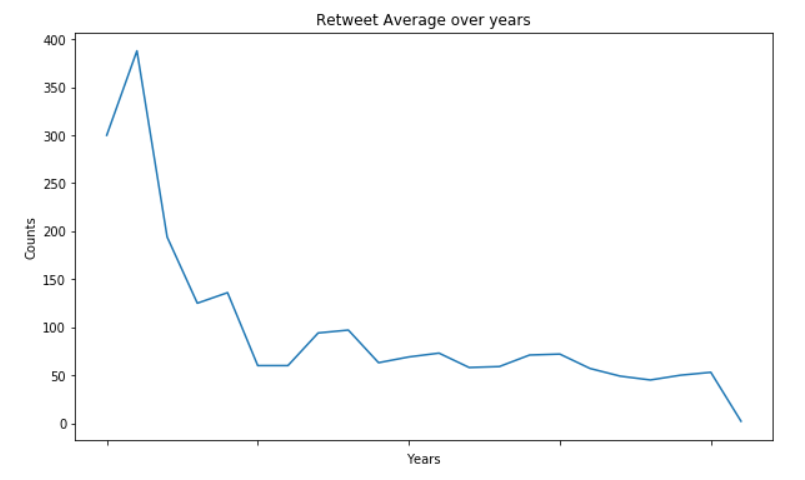

#### 2- What is the most popular dog stage?

As it is showen below, Pupper stage is the most popular with almost 250 count, when floofer is the least popular dog.

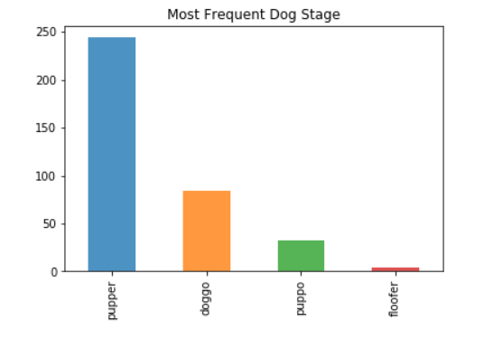

#### 3- Which dog stage has the most total retweets?

In this bar chart, it shows that the dog stage that has the most total retweets is Pupper, while the dog stage that has the lowest total retweets is Floofer.

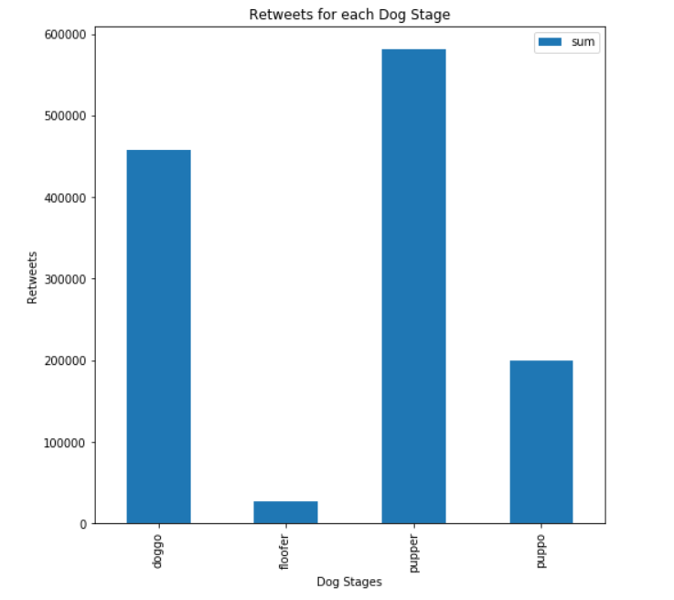